# Practice 8

Guglielmo Bonifazi, Emanuele Sorgente

7/12/2021

Excercise 1

Pre-processing

```r
library(e1071)
x11()
par(mfrow=c(1,3))
```

Given that, SVM is a method based on the distances it is essential to scale the predictors

```r
load(file.choose())
dataset_1=data.frame(cbind(scale(dataset_1[-3]),dataset_1[3]))
dataset_1$class=as.factor(dataset_1$class)
```

The SVM soft margin concept allows the model to cope with not linearly separable data. For instance, we admit the possibility to have instances inside the margin area ( and even incorrectly classified instances ), if the boundary will be able to produce a clearer class distinction, or in other terms to have a wider margin (the gap between the zones associated with the two classes). The cost parameter is governing the weight that the “errors” ( in fact, a misclassification will occur only if epsilon is greater than one ) will have on the objective function that determine the boundary. To better understand its role we can consider three examples.

Hard margin: cost–> Inf In this case the priority of the method will be to have the fewest number of instances in the margin area, even if this will lead to a small margin ( and so to a poor separation between the classes ). If the responses are, such as in this case, linearly separable, then there will be no observations inside the area.

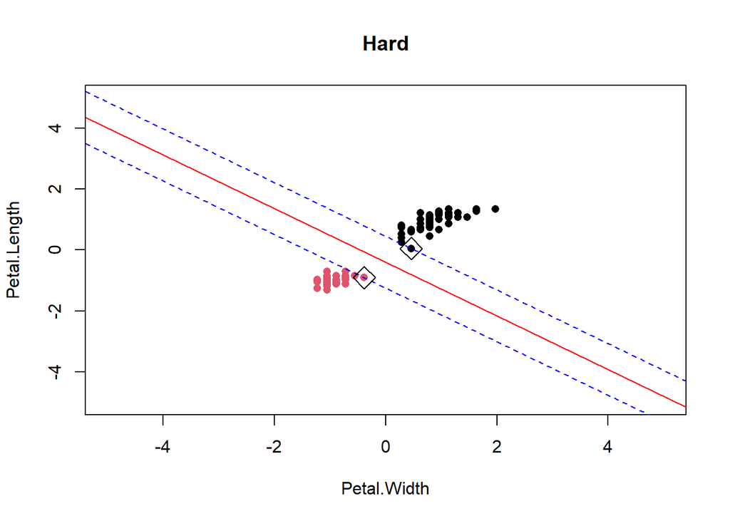

```r
m1=svm(class ~ Petal.Width + Petal.Length,
         data = dataset_1,
         kernel = "linear",
         cost = 100000)
plot(Petal.Length ~ Petal.Width, data = dataset_1, col = class, pch = 16,xlim=c(-5,5),ylim=c(-5,5),main='Hard')
cf = coef(m1)
abline(-cf[1]/cf[3], -cf[2]/cf[3], col = "red")
abline(-(cf[1] + 1)/cf[3], -cf[2]/cf[3], col = "blue", lty = 2)
abline(-(cf[1] - 1)/cf[3], -cf[2]/cf[3], col = "blue", lty = 2)
points(m1$SV, pch = 5, cex = 2)
```

Soft margin: Cost—>0 In this case the priority will be to produce the most clear distinction between the two classes, even if this will lead to some classifications errors. In this toy example, almost all the instances are inside the margin areas, but the division is net.

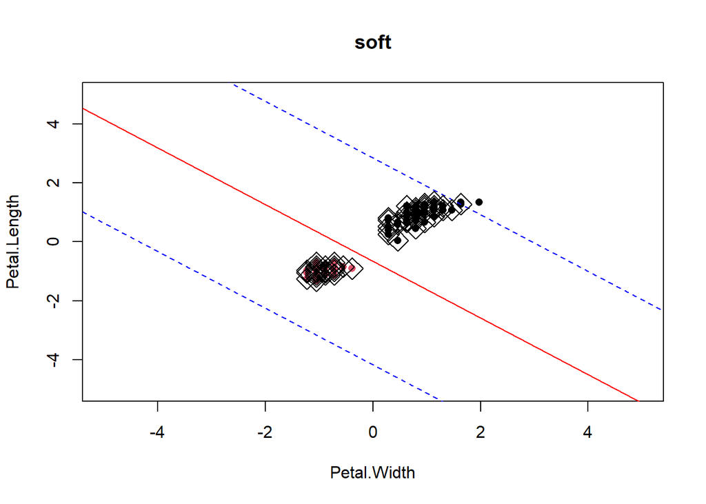

```r
m2=svm(class ~ Petal.Width + Petal.Length,
       data = dataset_1,
       kernel = "linear",
       cost = 0.003)
plot(Petal.Length ~ Petal.Width, data = dataset_1, col = class, pch = 16,xlim=c(-5,5),ylim=c(-5,5),main='soft')
cf = coef(m2)
abline(-cf[1]/cf[3], -cf[2]/cf[3], col = "red")
abline(-(cf[1] + 1)/cf[3], -cf[2]/cf[3], col = "blue", lty = 2)
abline(-(cf[1] - 1)/cf[3], -cf[2]/cf[3], col = "blue", lty = 2)
points(m2$SV, pch = 5, cex = 2)
```

Intermediate: This is a medium approach. Only few instances lay in the margin area in order to have a wider separation.

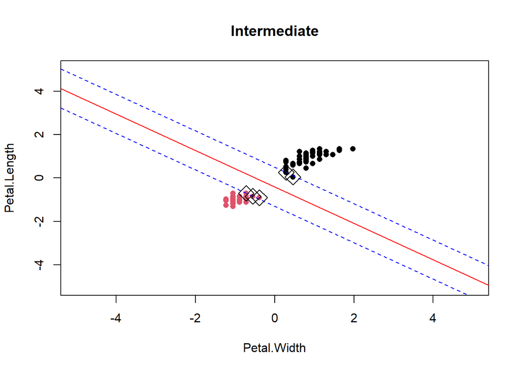

```r
m3=svm(class ~ Petal.Width + Petal.Length,
       data = dataset_1,
       kernel = "linear",
       cost = 0.5)
plot(Petal.Length ~ Petal.Width, data = dataset_1, col = class, pch = 16,xlim=c(-5,5),ylim=c(-5,5),main='Intermediate')
cf = coef(m3)
abline(-cf[1]/cf[3], -cf[2]/cf[3], col = "red")
abline(-(cf[1] + 1)/cf[3], -cf[2]/cf[3], col = "blue", lty = 2)
abline(-(cf[1] - 1)/cf[3], -cf[2]/cf[3], col = "blue", lty = 2)
points(m3$SV, pch = 5, cex = 2)
```

On Dataset1:

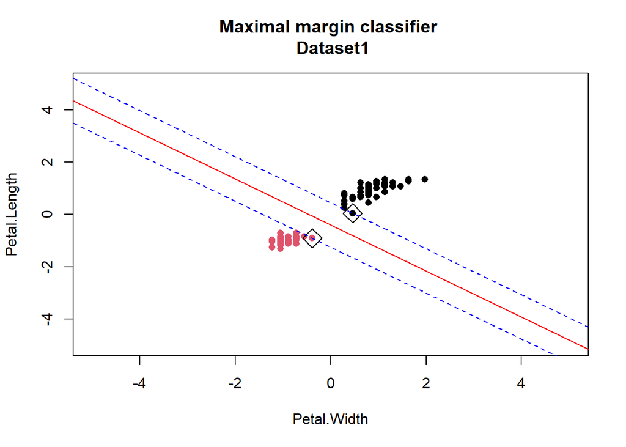

```r
plot(Petal.Length ~ Petal.Width, data = dataset_1, col = class, pch = 16,xlim=c(-5,5),ylim=c(-5,5),main='Maximal margin classifier \n Dataset1')
cf = coef(m1)
abline(-cf[1]/cf[3], -cf[2]/cf[3], col = "red")
abline(-(cf[1] + 1)/cf[3], -cf[2]/cf[3], col = "blue", lty = 2)
abline(-(cf[1] - 1)/cf[3], -cf[2]/cf[3], col = "blue", lty = 2)
points(m1$SV, pch = 5, cex = 2)
```

On dataset 2:

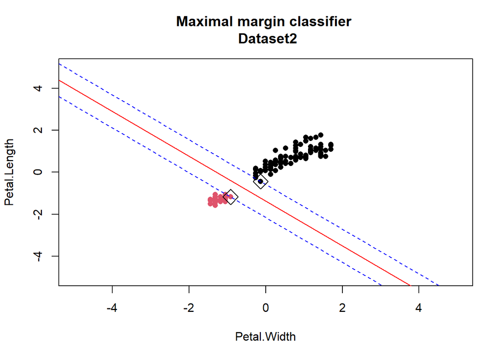

```r
dataset_2=data.frame(cbind(scale(dataset_2[-3]),dataset_2[3]))
dataset_2$class=as.factor(dataset_2$class)

mm_2=svm(class ~ Petal.Width + Petal.Length,
       data = dataset_2,
       kernel = "linear",
       cost = 100000)

plot(Petal.Length ~ Petal.Width, data = dataset_2, col = class, pch = 16,xlim=c(-5,5),ylim=c(-5,5),main='Maximal margin classifier \n Dataset2')
cf = coef(mm_2)
abline(-cf[1]/cf[3], -cf[2]/cf[3], col = "red")
abline(-(cf[1] + 1)/cf[3], -cf[2]/cf[3], col = "blue", lty = 2)
abline(-(cf[1] - 1)/cf[3], -cf[2]/cf[3], col = "blue", lty = 2)
points(mm_2$SV, pch = 5, cex = 2)
```

On dataset3

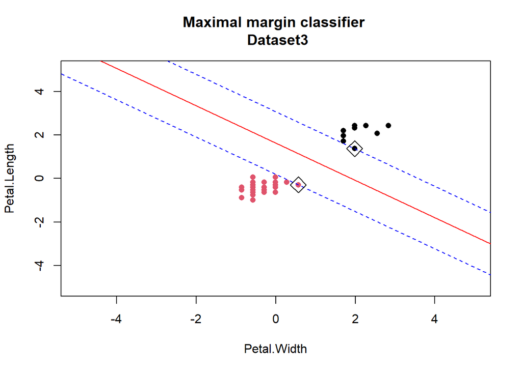

```r
dataset_3=data.frame(cbind(scale(dataset_3[-3]),dataset_3[3]))
dataset_3$class=as.factor(dataset_3$class)

mm_3=svm(class ~ Petal.Width + Petal.Length,
         data = dataset_3,
         kernel = "linear",
         cost = 100000)

plot(Petal.Length ~ Petal.Width, data = dataset_3, col = class, pch = 16,xlim=c(-5,5),ylim=c(-5,5),main='Maximal margin classifier \n Dataset3')
cf = coef(mm_3)
abline(-cf[1]/cf[3], -cf[2]/cf[3], col = "red")
abline(-(cf[1] + 1)/cf[3], -cf[2]/cf[3], col = "blue", lty = 2)
abline(-(cf[1] - 1)/cf[3], -cf[2]/cf[3], col = "blue", lty = 2)
points(mm_3$SV, pch = 5, cex = 2)
```

Excercise 2

```r
library(caret)
data=read.csv(file.choose())
data$output=as.factor(data$output)
```

We will use the following approach: A 5-fold cross validation will be used to assess the Hyperparameter tuning and the model selection. In particular, we will tune three models, one for kernel, and then we will compare the estimated accuracy. Once that the model has been selected, it will be evaluated with a testing set previously excluded by the data, and so not used for the training.

Preprocessing for HPO:

```r
in_train_set=createDataPartition(data$output, p = .75, list = FALSE)#list=false is to make the outcome of our function a list
train = data[in_train_set, ]
test = data[-in_train_set, ]
ctrl=trainControl(method = "cv",
                  number = 5)
```

Linear:

```r
grid=expand.grid(C=c(seq(0.001,1,length.out=50),seq(2,50,length.out=50)))
set.seed(7)
mod_lin = train( output~ .,
             data = train,
             method = "svmLinear",
             verbose = FALSE,
             metric = "Accuracy",
             tuneGrid = grid,
             trControl = ctrl,
             random_state=42)
mod_lin$bestTune
```

```
##            C
## 3 0.04177551
```

```r
score_lin=max(mod_lin$results['Accuracy'])
```

Polinomial:

```r
grid=expand.grid(C=c(seq(0.001,1,length.out=20),seq(2,50,length.out=20)),degree=2:6,scale=0.01)
set.seed(7)
mod_poly = train( output~ .,
                 data = train,
                 method = "svmPoly",
                 verbose = FALSE,
                 metric = "Accuracy",
                 tuneGrid = grid,
                 trControl = ctrl,
                 random_state=42)
mod_poly$bestTune
```

```
##    degree scale         C
## 49      5  0.01 0.4742105
```

```r
score_poly=max(mod_poly$results['Accuracy'])
```

Gaussian:

```r
grid=expand.grid(C=c(seq(0.001,1,length.out=20),seq(2,25,length.out=10)),sigma=c(0.001,0.01,0.1,1,100,1000))
set.seed(7)
mod_gaus = train( output~ .,
                  data = train,
                  method = "svmRadial",
                  verbose = FALSE,
                  metric = "Accuracy",
                  tuneGrid = grid,
                  trControl = ctrl,
                  random_state=42)
mod_gaus$bestTune
```

```
##     sigma C
## 122  0.01 2
```

```r
score_gaus=max(mod_gaus$results['Accuracy'])
c(score_lin,score_poly,score_gaus)
```

```
## [1] 0.8247343 0.8290821 0.8247343
```

```r
y_hat=predict(mod_gaus,test[-14])
t=table(test[,14],y_hat)
acc=(t[1,1]+t[2,2])/nrow(test)
acc
```

```
## [1] 0.8666667
```